# R Assignment 4

```r
summary(ChiSubs20)
```

```
##    Min. 1st Qu.  Median    Mean 3rd Qu.    Max.
## 0.03434 0.30987 0.53186 1.23980 1.62163 5.75437
```

```r
summary(ChiSubs30)
```

```
##    Min. 1st Qu.  Median    Mean 3rd Qu.    Max.
## 0.03434 0.34600 1.10074 1.51396 2.28392 5.75437
```

```r
summary(ChiSubs50)
```

```
##    Min. 1st Qu.  Median    Mean 3rd Qu.    Max.
## 0.03434 0.43565 1.19880 1.55241 2.33072 5.75437
```

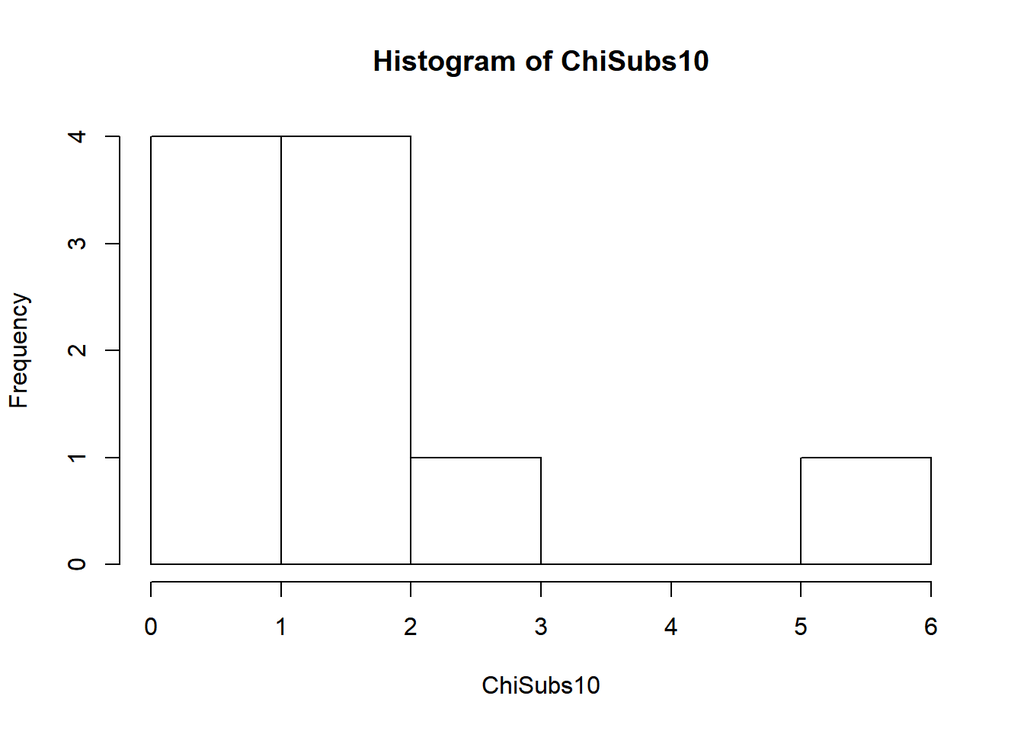

```r
hist(ChiSubs10)
```

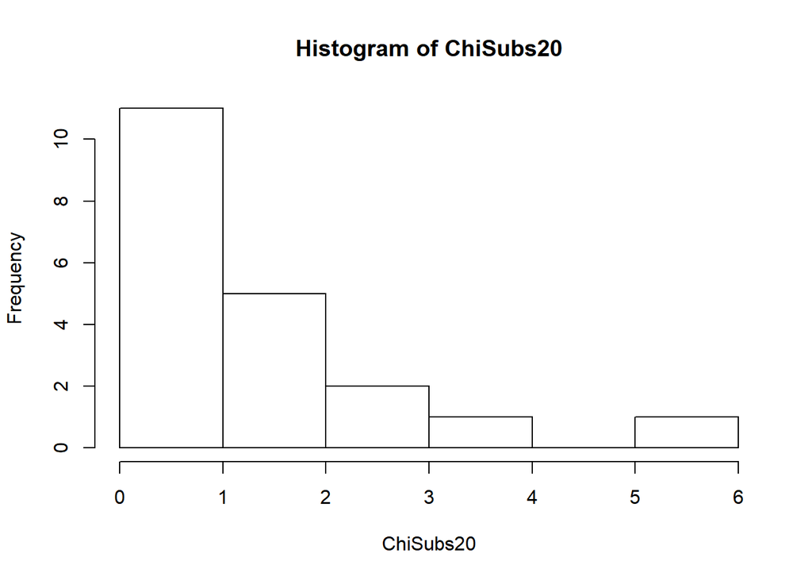

```r
hist(ChiSubs20)
```

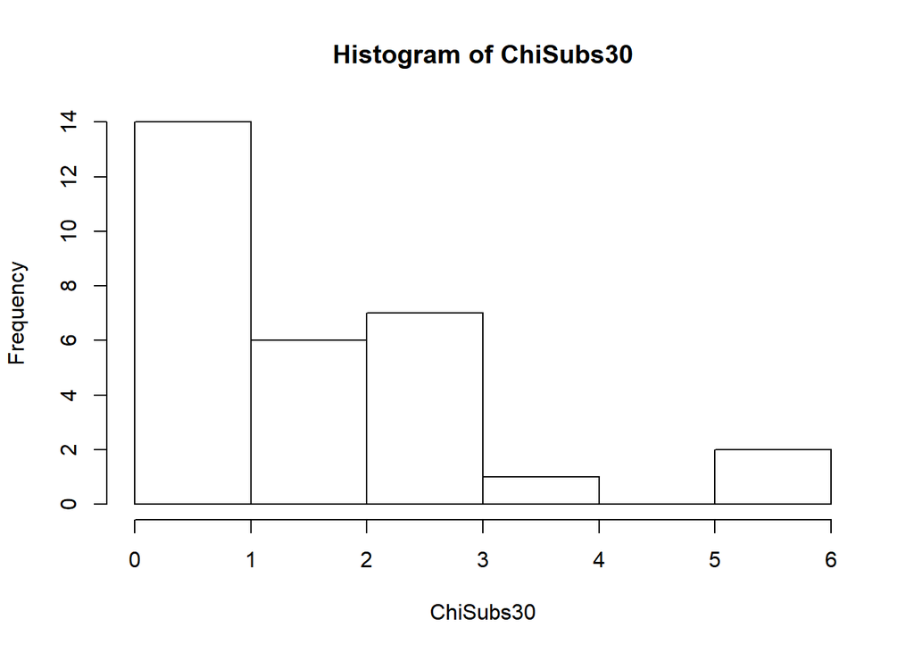

```r
hist(ChiSubs30)
```

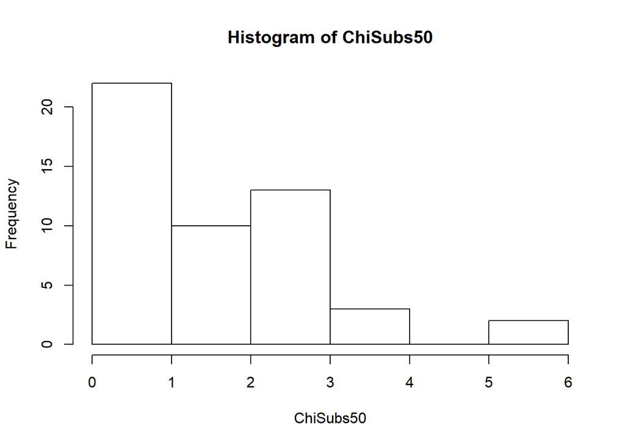

```r
hist(ChiSubs50)
```

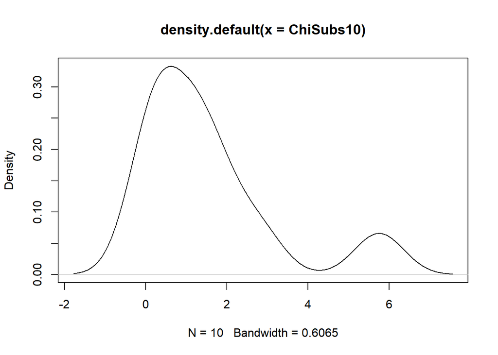

```r
plot(density(ChiSubs10))
```

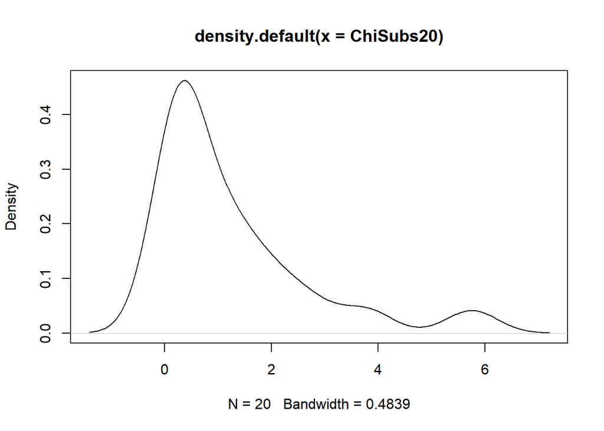

```r
plot(density(ChiSubs20))
```

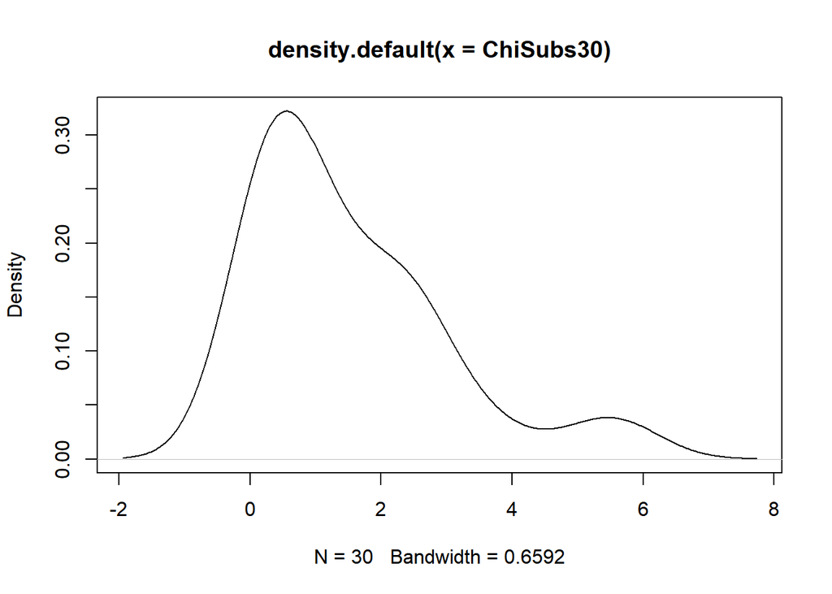

```r
plot(density(ChiSubs30))
```

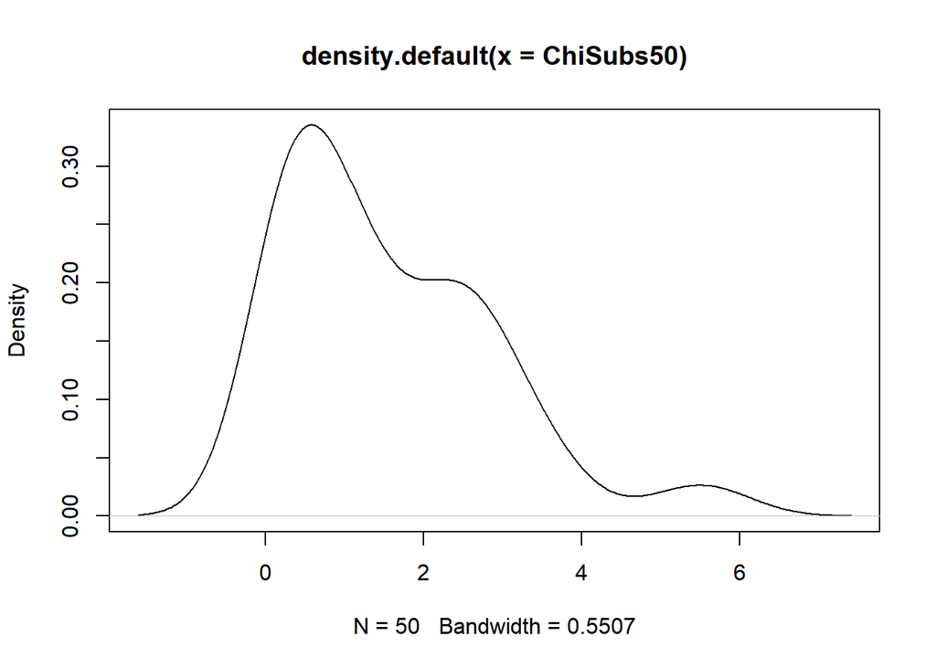

```r
plot(density(ChiSubs50))
```

```r
var(ChiSubs10)
```

```
## [1] 2.974062
```

```r
var(ChiSubs20)
```

```
## [1] 2.152357
```

```r
var(ChiSubs30)
```

```
## [1] 2.211067
```

```r
var(ChiSubs50)
```

```
## [1] 1.790028
```

$F$-Distribution: as sample size increases, it is still difficult to recognize if it is a normal or skewed distribution.

```r
FSubs10<- xFd_n10000[1:10]
summary(FSubs10)
```

```
##    Min. 1st Qu.  Median    Mean 3rd Qu.    Max.
##  0.5374  0.7006  1.0532  1.1032  1.3596  2.2585
```

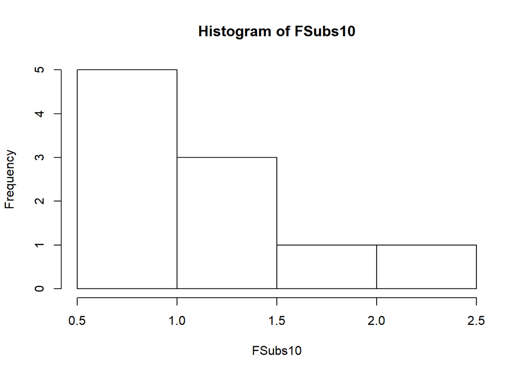

```r
hist(FSubs10)
```

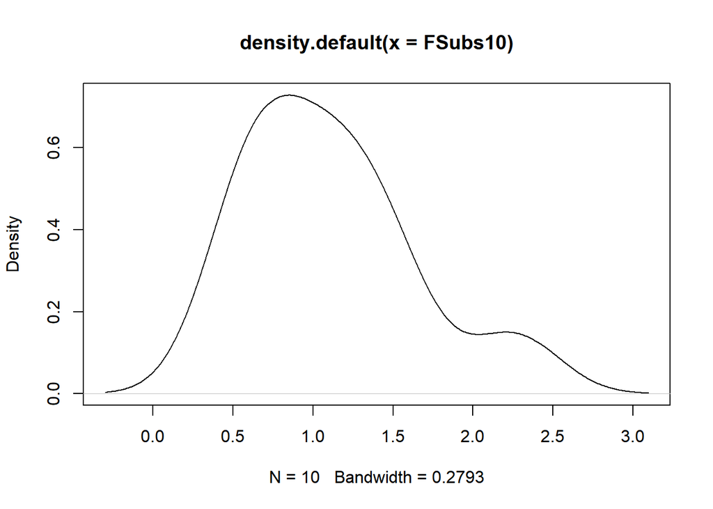

```r
plot(density(FSubs10))
```

```r
FSubs20<- xFd_n10000[1:20]
summary(FSubs20)
```

```
##    Min. 1st Qu.  Median    Mean 3rd Qu.    Max.
##  0.4773  0.6777  1.1642  1.1271  1.3709  2.2585
```

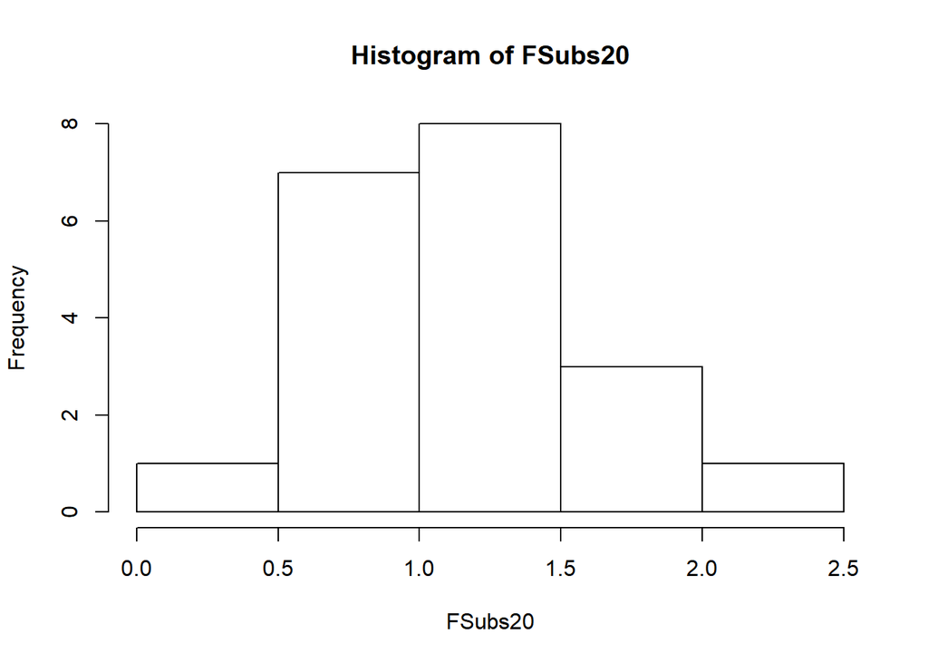

```r
hist(FSubs20)
```

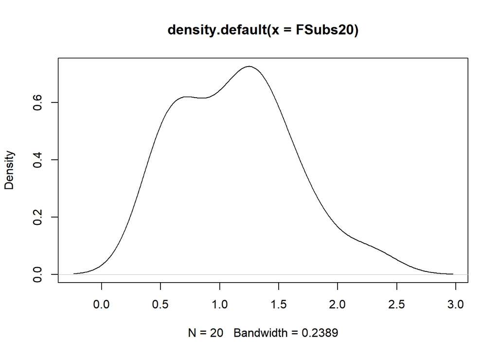

```r
plot(density(FSubs20))
```

```r
FSubs30<- xFd_n10000[1:30]
summary(FSubs30)
```

```
##    Min. 1st Qu.  Median    Mean 3rd Qu.    Max.
##  0.4773  0.7089  1.1642  1.1179  1.3487  2.2585
```

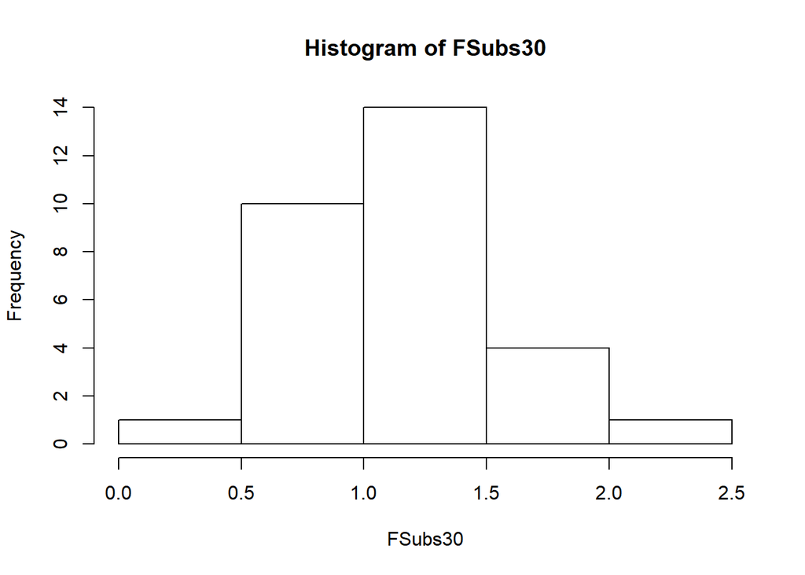

```r
hist(FSubs30)
```

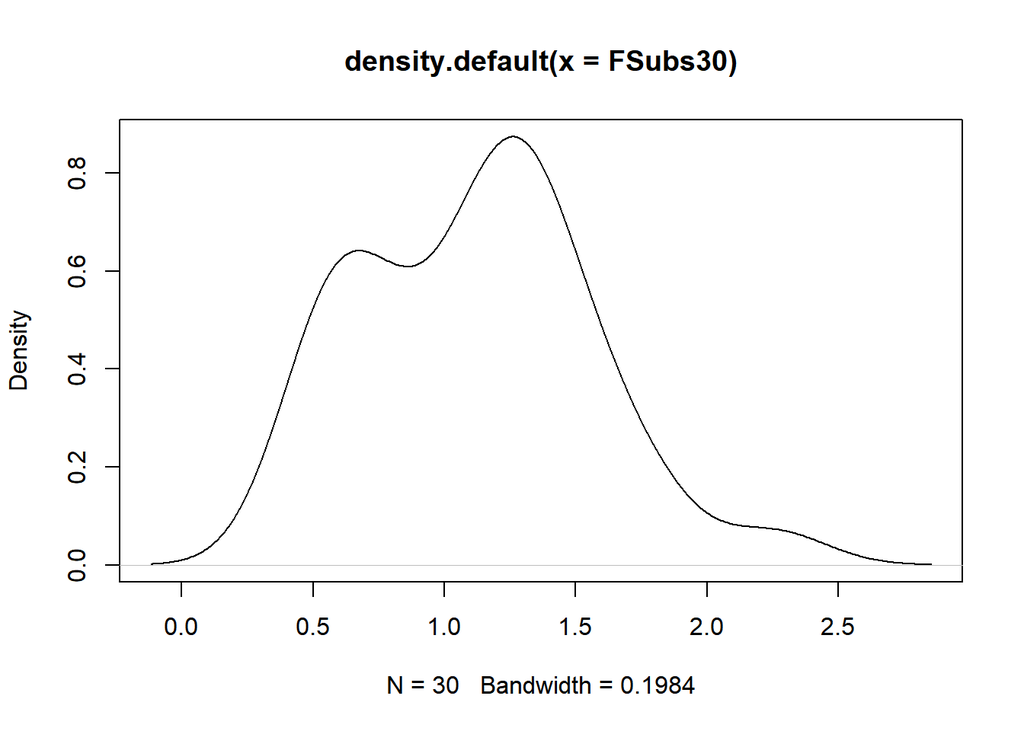

```r
plot(density(FSubs30))
```

```r
FSubs50<- xFd_n10000[1:50]
summary(FSubs50)
```

```
##    Min. 1st Qu.  Median    Mean 3rd Qu.    Max.
##  0.4562  0.6985  1.1751  1.1669  1.4245  2.9828
```

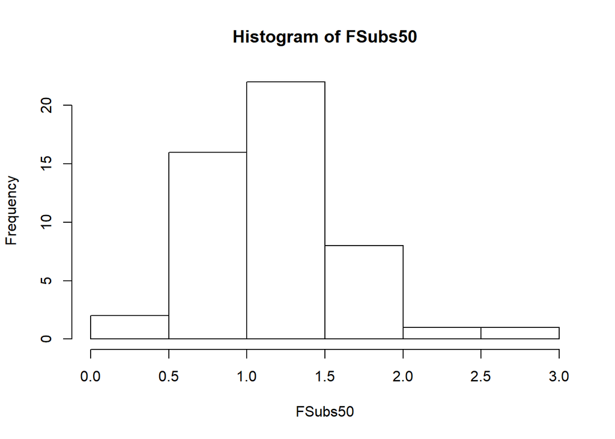

```r
hist(FSubs50)
```

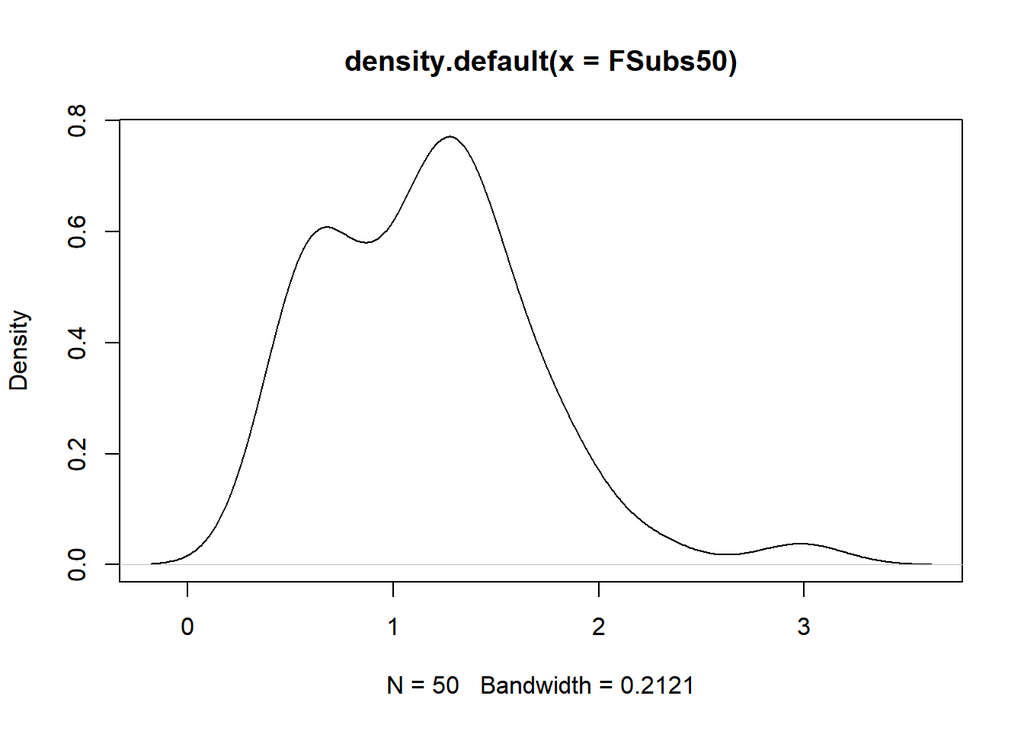

```r
plot(density(FSubs50))
```

```r
var(FSubs10)
```

```
## [1] 0.2821754
```

```r
var(FSubs20)
```

```
## [1] 0.2335248
```

```r
var(FSubs30)
```

```
## [1] 0.189363
```

```r
var(FSubs50)
```

```
## [1] 0.2654681
```

Binomial: as sample size increases, the distribution becoming look normal.

```r
BDSubs10<- xBD_n10000[1:10]
summary(BDSubs10)
```

```
##    Min. 1st Qu.  Median    Mean 3rd Qu.    Max.
##     4.0     5.0     5.5     5.9     7.0     8.0
```

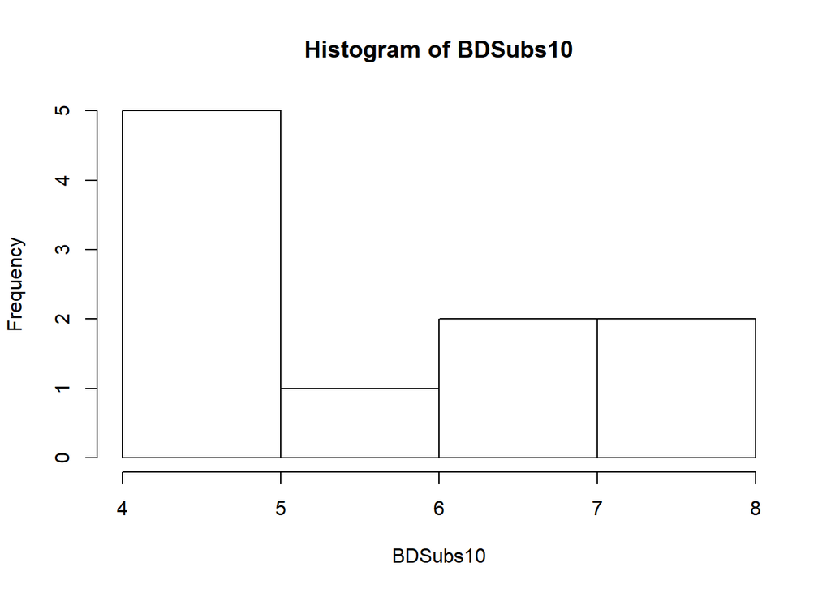

```r
hist(BDSubs10)
```

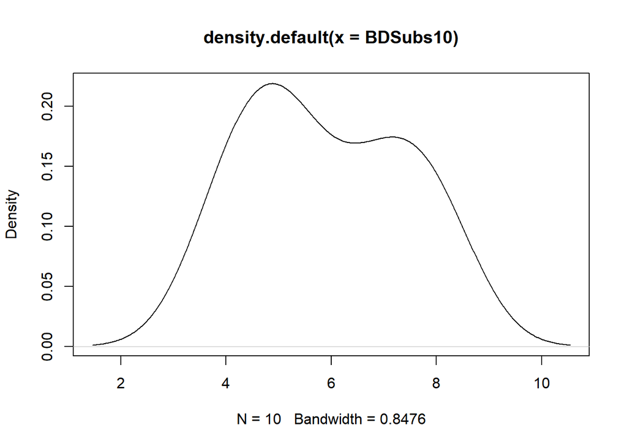

```r
plot(density(BDSubs10))
```

```r
BDSubs20<- xBD_n10000[1:20]
summary(BDSubs20)
```

```
##    Min. 1st Qu.  Median    Mean 3rd Qu.    Max.
##       4       5       6       6       7       8
```

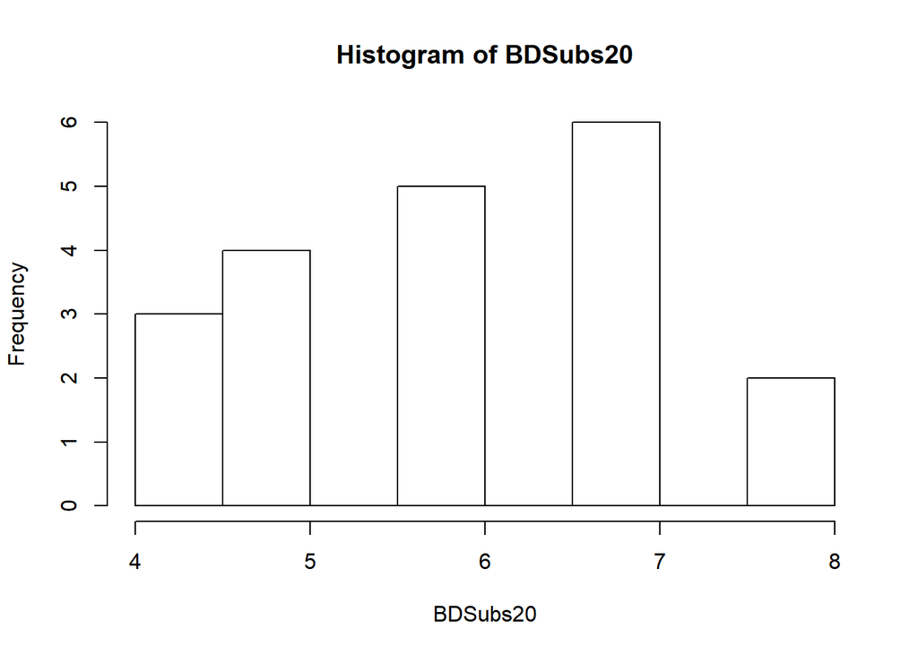

```r
hist(BDSubs20)
```

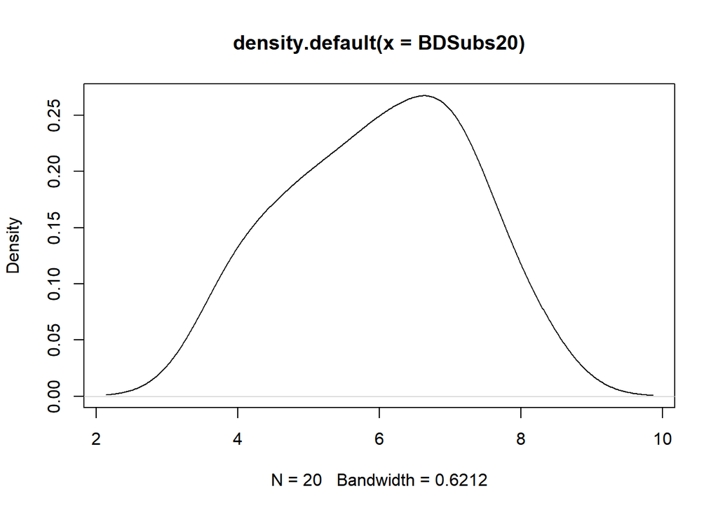

```r
plot(density(BDSubs20))
```

```r
BDSubs30<- xBD_n10000[1:30]
summary(BDSubs30)
```

```
##    Min. 1st Qu.  Median    Mean 3rd Qu.    Max.
##   3.000   5.000   6.000   5.933   7.000   8.000
```

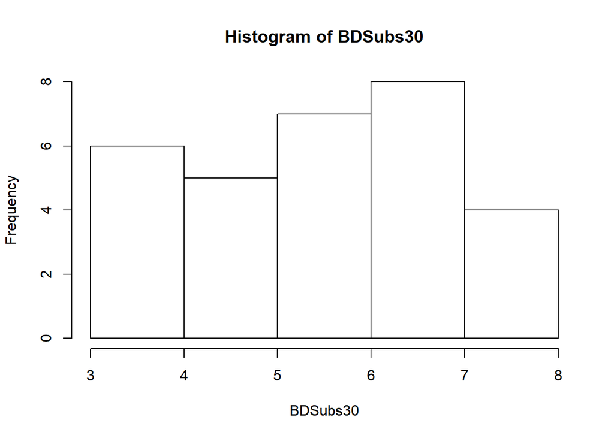

```r
hist(BDSubs30)
```

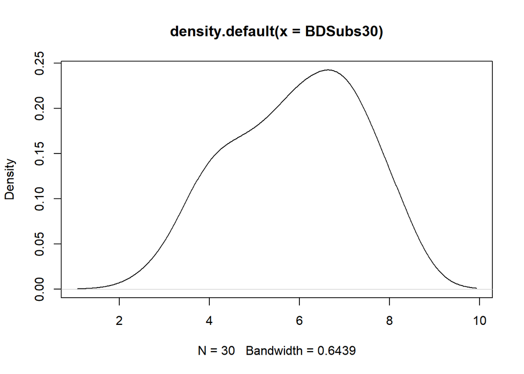

```r
plot(density(BDSubs30))
```

```r
BDSubs50<- xBD_n10000[1:50]
summary(BDSubs50)
```

```
##    Min. 1st Qu.  Median    Mean 3rd Qu.    Max.
##    3.00    5.00    6.00    6.06    7.00    9.00
```

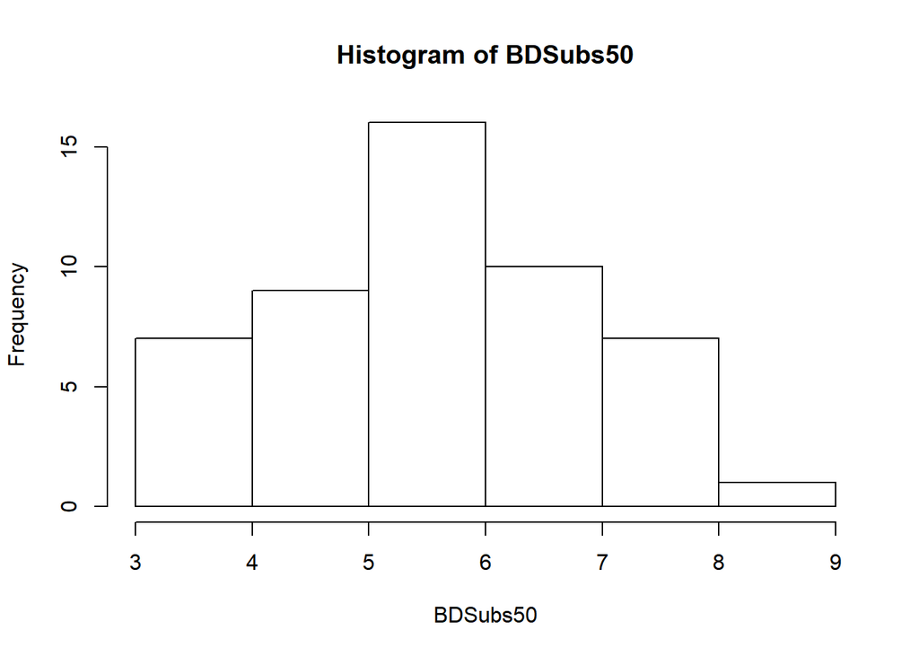

```r
hist(BDSubs50)
```

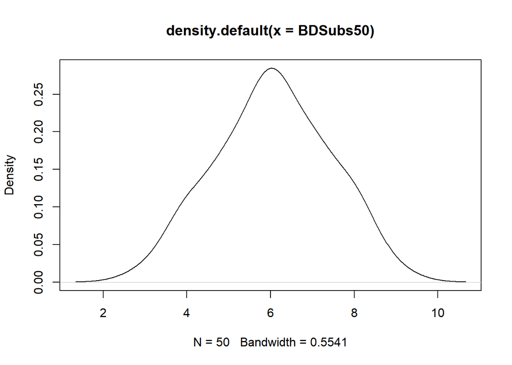

```r
plot(density(BDSubs50))
```

```r
var(BDSubs10)
```

```
## [1] 2.322222
```

```r
var(BDSubs20)
```

```
## [1] 1.578947
```

```r
var(BDSubs30)
```

```
## [1] 1.995402
```

```r
var(BDSubs50)
```

```
## [1] 1.812653
```

Negative binomial: as sample soze increases, the plot becomes more skewed.

```r
NegSubs10<- xNB_n10000[1:10]
NegSubs20<- xNB_n10000[1:20]
NegSubs30<- xNB_n10000[1:30]
NegSubs50<- xNB_n10000[1:50]

summary(NegSubs10)
```

```
##    Min. 1st Qu.  Median    Mean 3rd Qu.    Max.
##     2.0     3.0     4.5     5.0     7.0     9.0
```

```r
summary(NegSubs20)
```

```
##    Min. 1st Qu.  Median    Mean 3rd Qu.    Max.
##    2.00    3.00    5.50    6.20    8.25   15.00
```

```r
summary(NegSubs30)
```

```
##    Min. 1st Qu.  Median    Mean 3rd Qu.    Max.
##   2.000   3.250   5.000   5.767   7.000  15.000
```

```r
summary(NegSubs50)
```

```
##    Min. 1st Qu.  Median    Mean 3rd Qu.    Max.
##    0.00    3.00    5.00    5.38    7.00   15.00
```

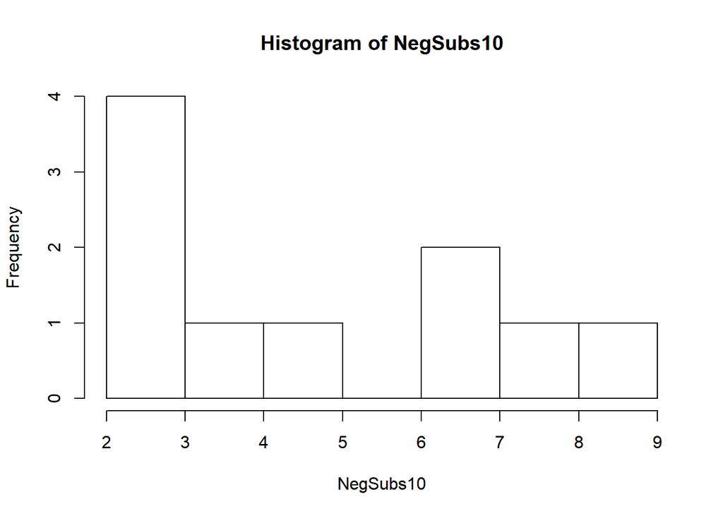

```r
hist(NegSubs10)
```

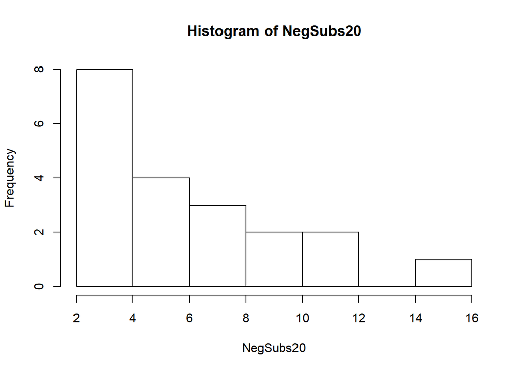

```r
hist(NegSubs20)
```

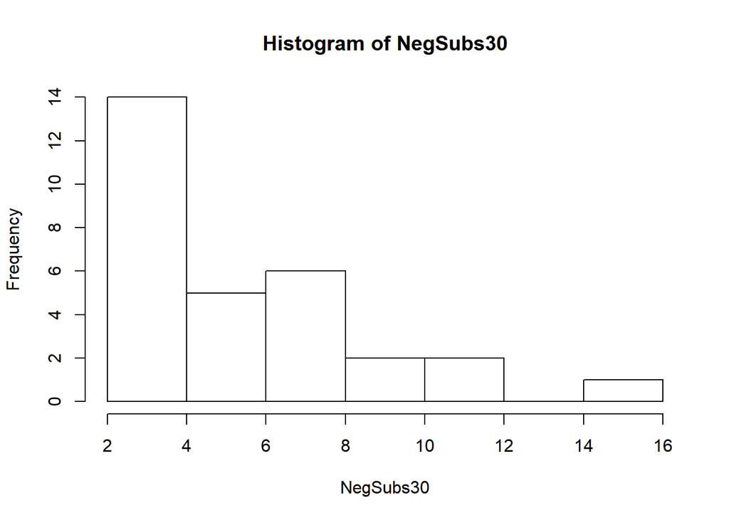

```r
hist(NegSubs30)
```

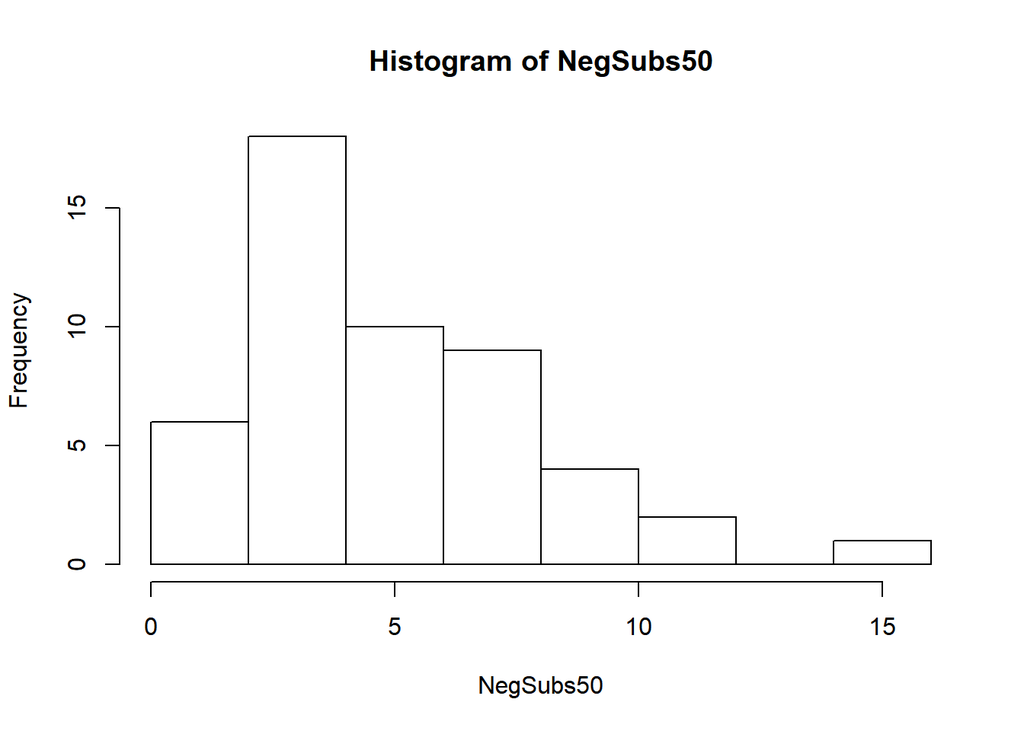

```r
hist(NegSubs50)
```

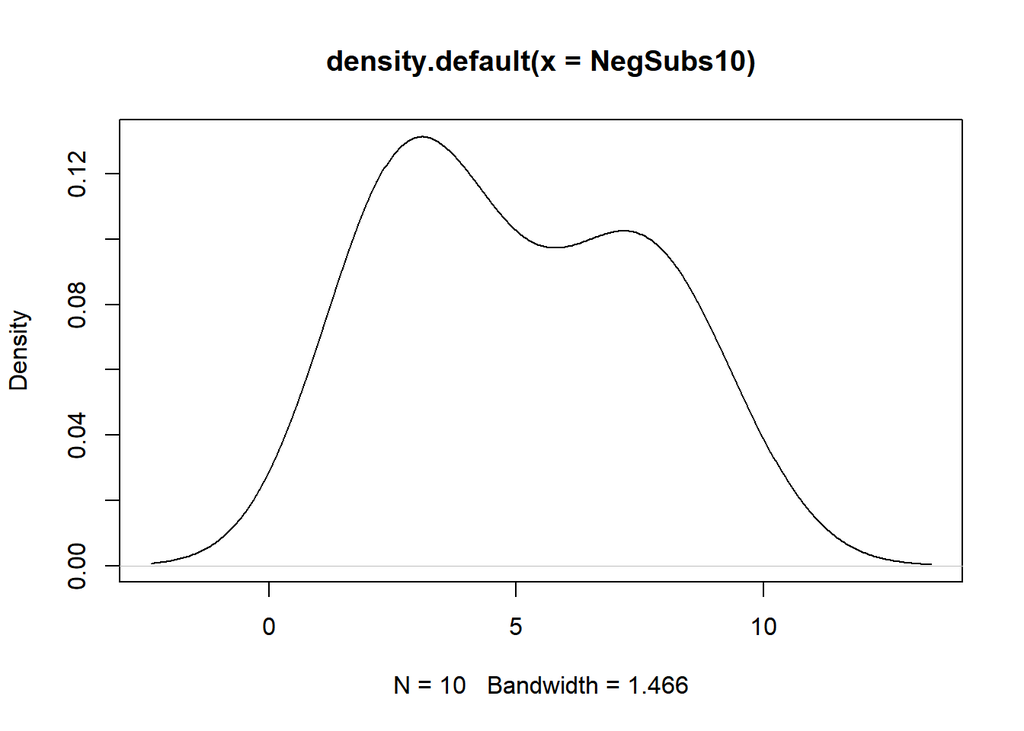

```r
plot(density(NegSubs10))
```

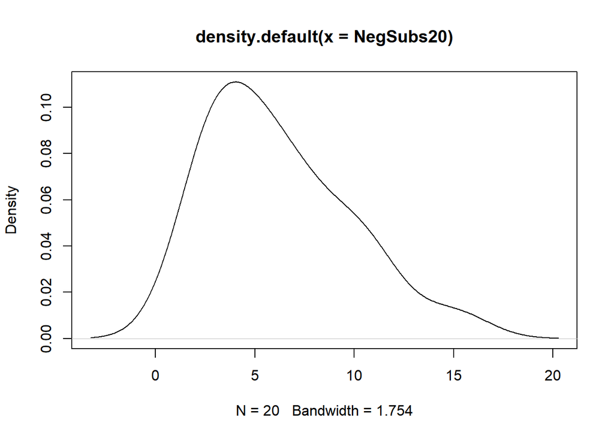

```r
plot(density(NegSubs20))
```

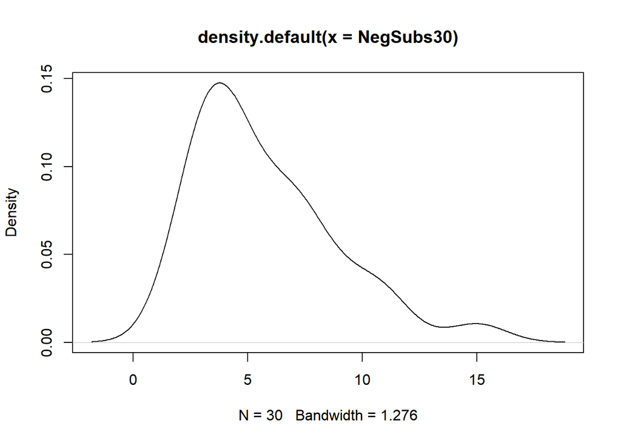

```r
plot(density(NegSubs30))
```

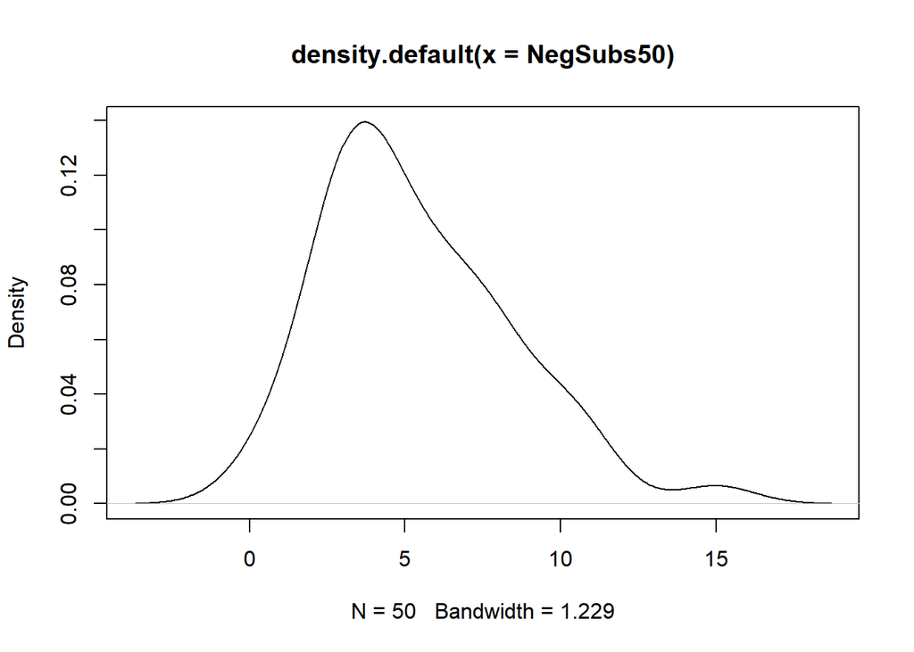

```r
plot(density(NegSubs50))
```

Poisson: as sample size increases, the distribution becomes clearely skewed.

```r
PoisSubs10<- xP_n10000[1:10]
PoisSubs20<- xP_n10000[1:20]
PoisSubs30<- xP_n10000[1:30]
PoisSubs50<- xP_n10000[1:50]

summary(PoisSubs10)
```

```
##    Min. 1st Qu.  Median    Mean 3rd Qu.    Max.
##    1.00    1.25    2.00    3.10    3.75    8.00
```

```r
summary(PoisSubs20)
```

```
##    Min. 1st Qu.  Median    Mean 3rd Qu.    Max.
##    0.00    1.00    2.00    2.75    3.25    8.00
```

```r
summary(PoisSubs30)
```

```
##    Min. 1st Qu.  Median    Mean 3rd Qu.    Max.
##   0.000   1.250   2.500   3.267   4.000   9.000
```

```r
summary(PoisSubs50)
```

```
##    Min. 1st Qu.  Median    Mean 3rd Qu.    Max.
##    0.00    2.00    3.00    3.32    4.75    9.00
```

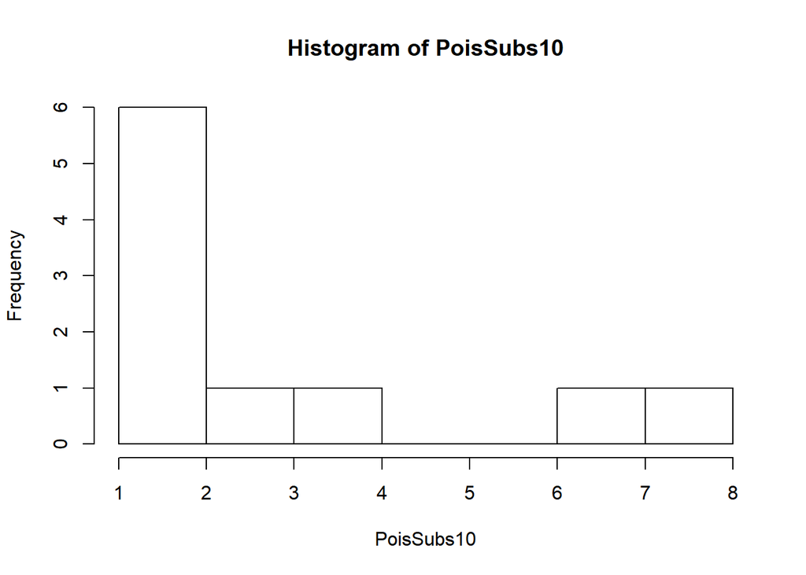

```r
hist(PoisSubs10)
```

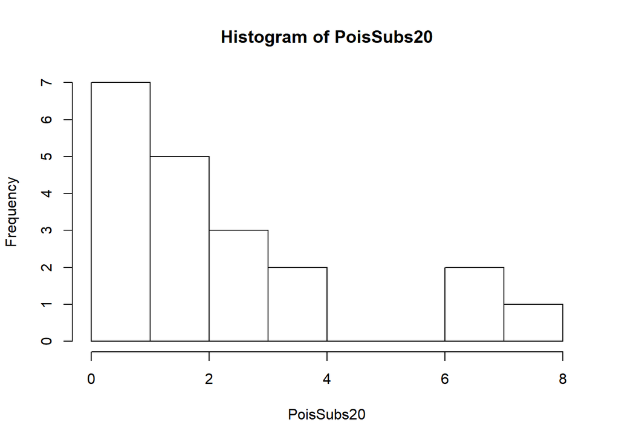

```r
hist(PoisSubs20)
```

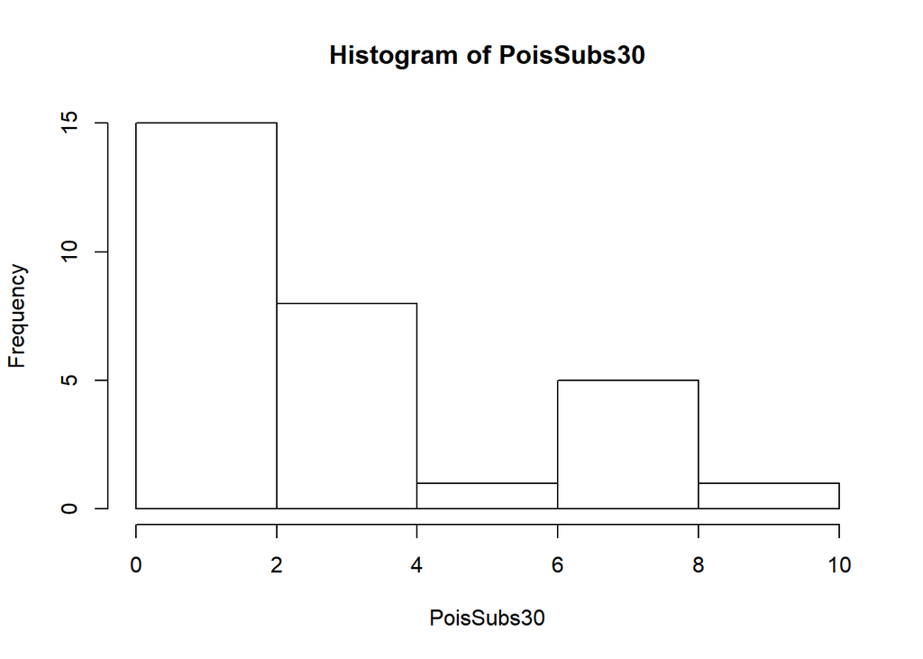

```r
hist(PoisSubs30)
```

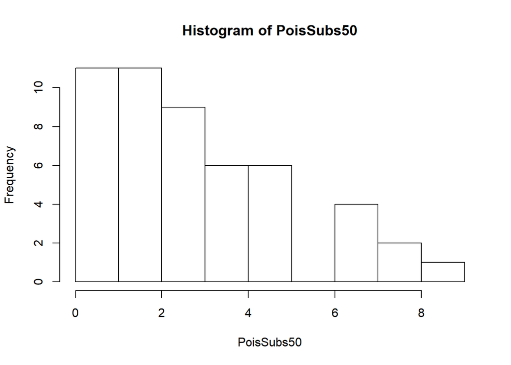

```r
hist(PoisSubs50)
```

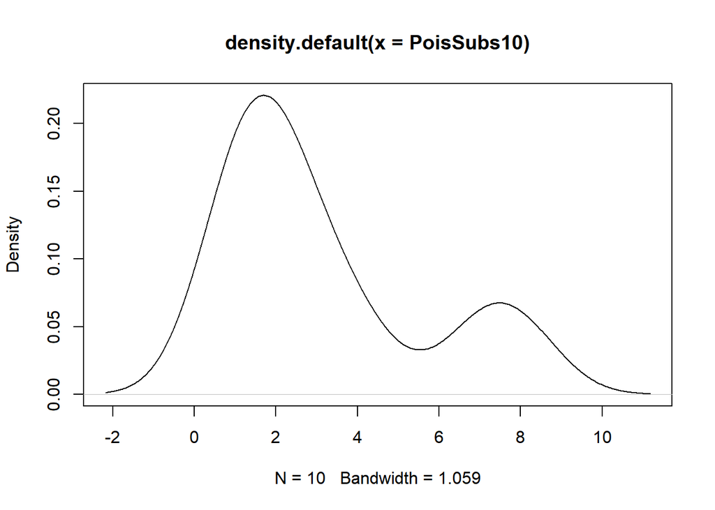

```r
plot(density(PoisSubs10))
```

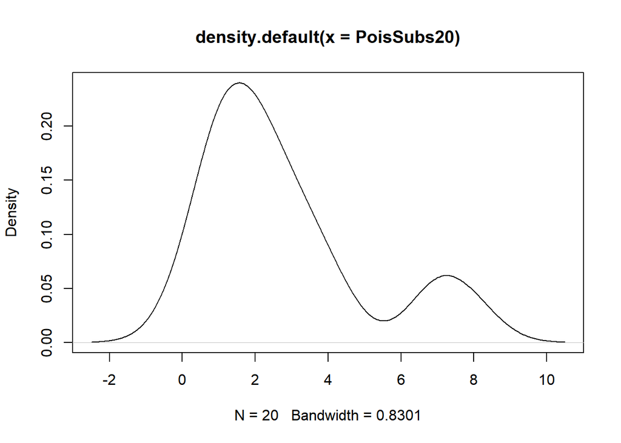

```r
plot(density(PoisSubs20))
```

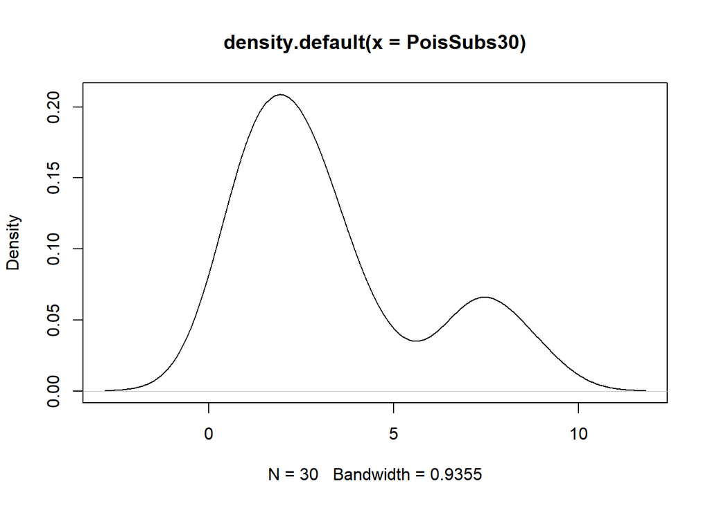

```r
plot(density(PoisSubs30))
```

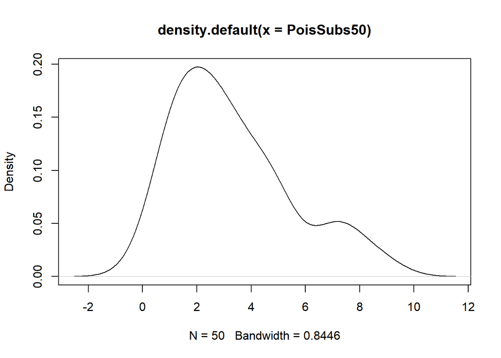

```r
plot(density(PoisSubs50))
```

### 4. Repeat Item 2 for the entire vector ($N = 10000$). For smaller values of $N$ from continuous distributions, which tool do you think gave a better representation of the full data: histogram or density plot? Did this change when you inspected the discrete distributions?

Histogram gives a better representation of a small sample size of continuous distributions. A histogram is best for small sample sizes of the discrete distrebutions. Density function grapth is a bad representation of a samall samples of distributions.

Normal - continuous

```r
summary(xNorm_n10000)
```

```
##    Min. 1st Qu.  Median    Mean 3rd Qu.    Max.
## -6.2093  0.4942  1.9644  1.9854  3.5153 10.5200
```

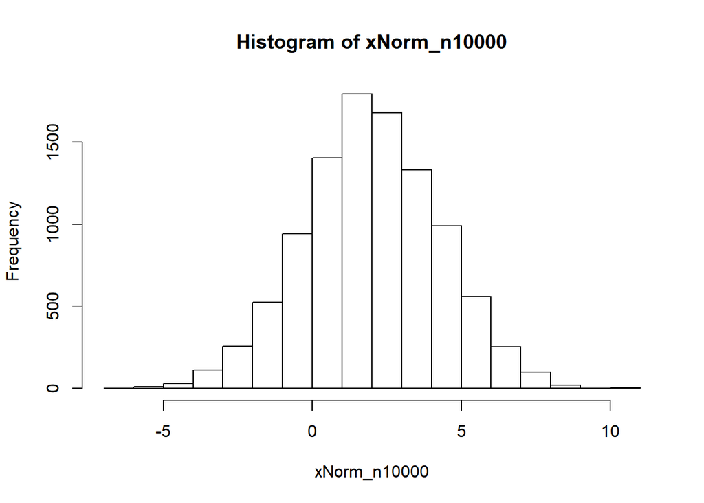

```r
hist(xNorm_n10000)
```

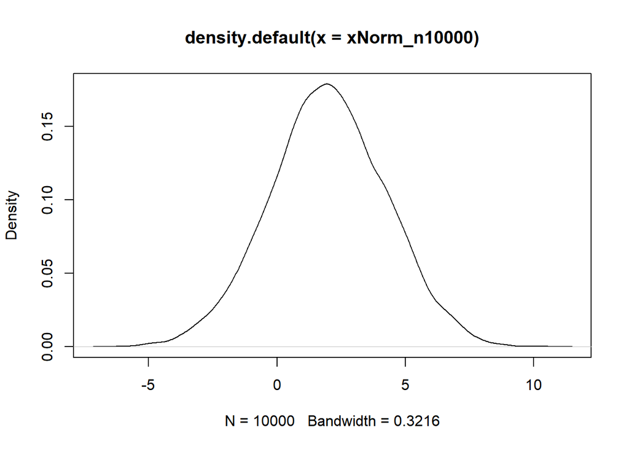

```r
plot(density(xNorm_n10000))
```

```r
var(xNorm_n10000)
```

```
## [1] 5.124328
```

Student’s $t$ continuous

```r
summary(xrt_n10000)
```

```
##       Min.    1st Qu.     Median       Mean    3rd Qu.       Max.
## -16.581973  -0.744999  -0.004989  -0.014118   0.742671  13.393131
```

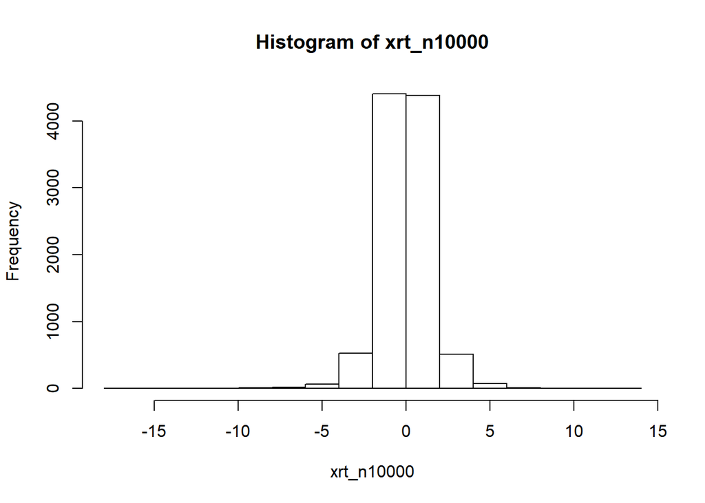

```r
hist(xrt_n10000)
```

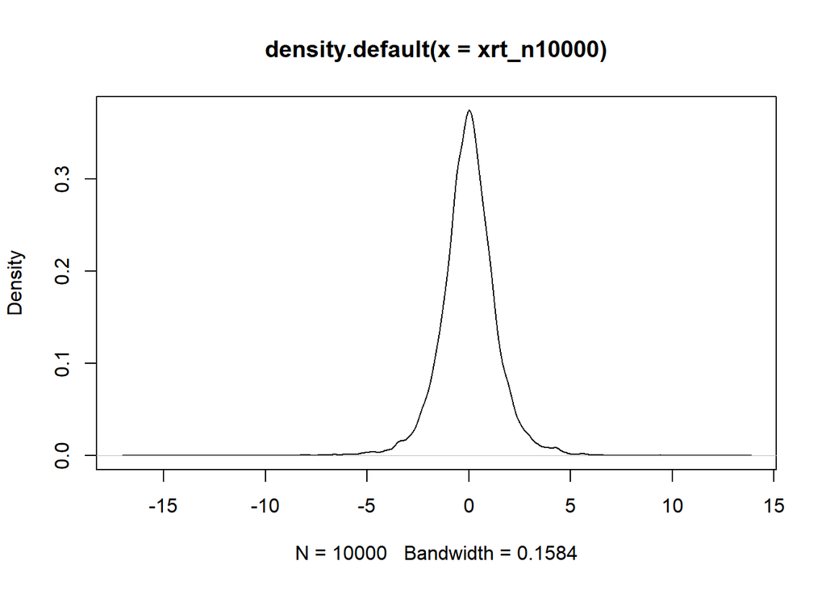

```r
plot(density(xrt_n10000))
```

$\chi ^ 2$ continuous skewed

```r
summary(xChi_n10000)
```

```
##      Min.   1st Qu.    Median      Mean   3rd Qu.      Max.
##  0.001041  0.597095  1.416917  2.042354  2.818150 24.146697
```

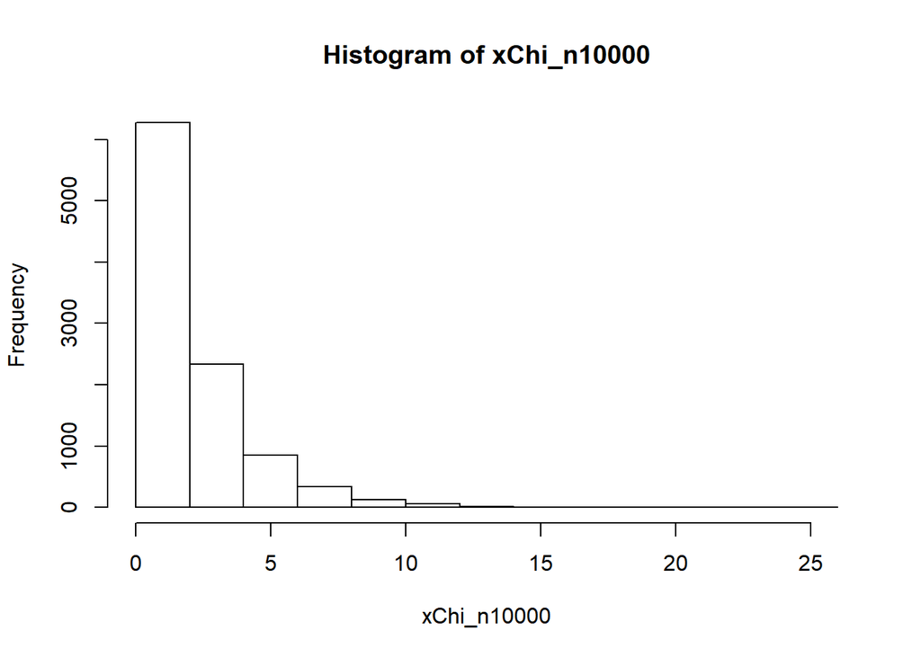

```r
hist(xChi_n10000)
```

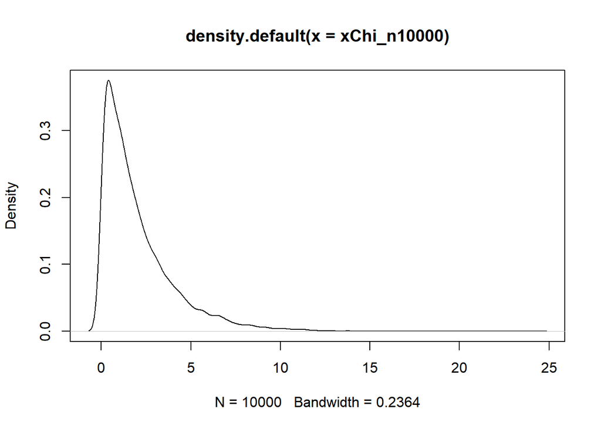

```r
plot(density(xChi_n10000))
```

$F$-Distribution - continuous

```r
summary(xFd_n10000)
```

```
##    Min. 1st Qu.  Median    Mean 3rd Qu.    Max.
##  0.2492  0.7955  1.0512  1.1985  1.4383  7.3203
```

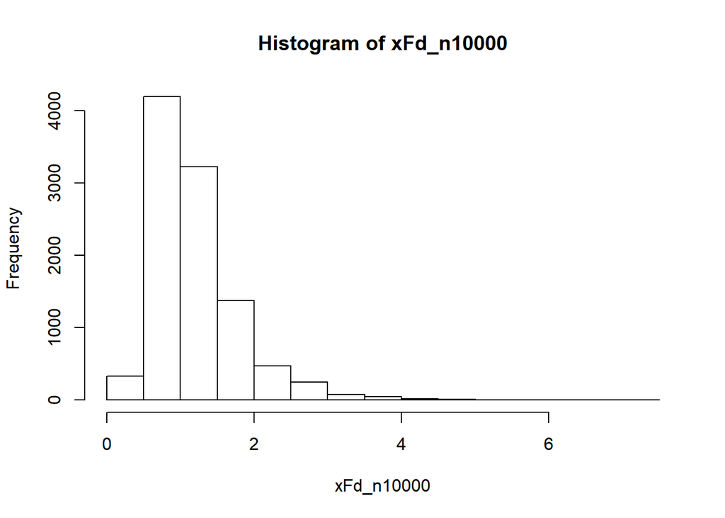

```r
hist(xFd_n10000)
```

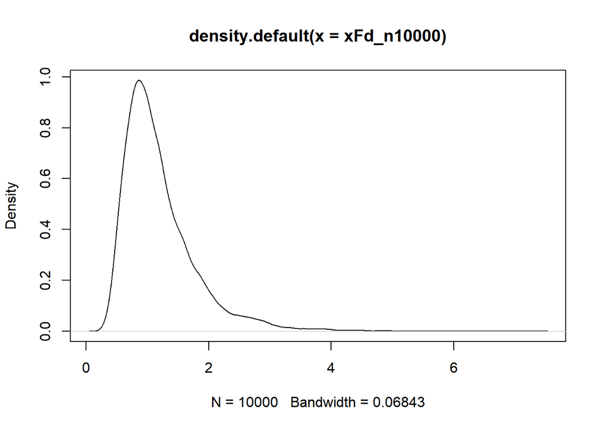

```r
plot(density(xFd_n10000))
```

Binomial - discrete

```r
summary(xBD_n10000)
```

```
##    Min. 1st Qu.  Median    Mean 3rd Qu.    Max.
##   1.000   5.000   6.000   5.992   7.000   9.000
```

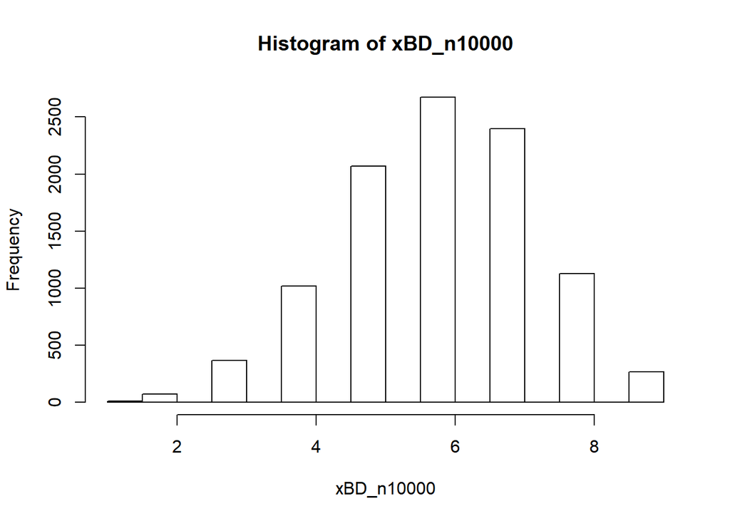

```r
hist(xBD_n10000)
```

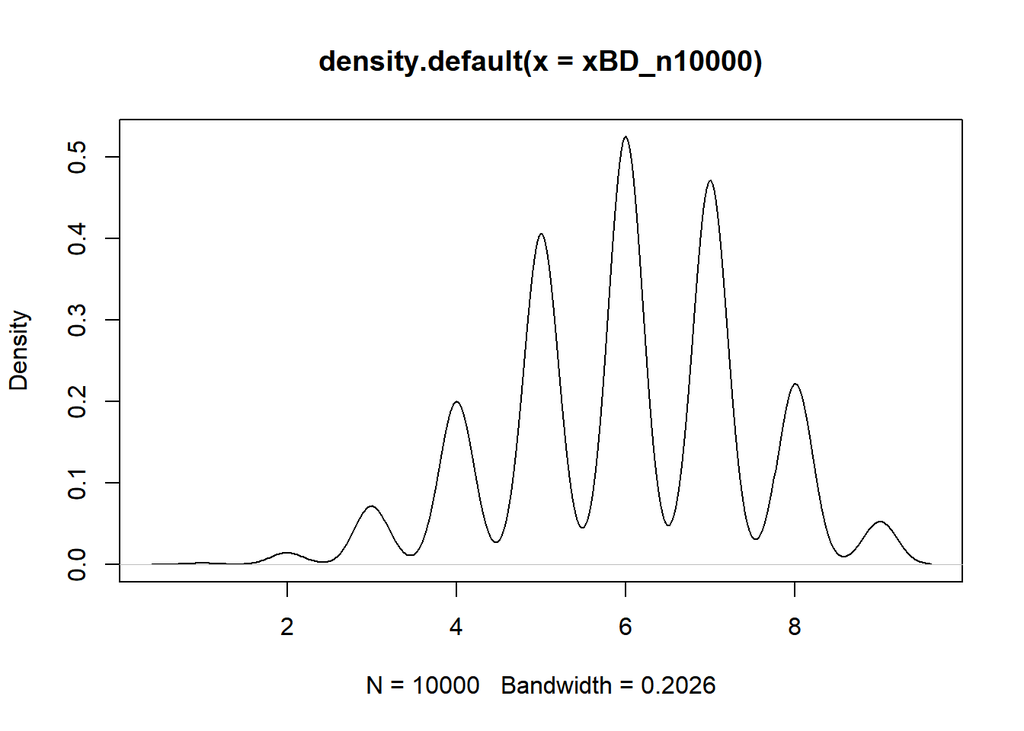

```r
plot(density(xBD_n10000))
```

Negative binomial - discrete

```r
summary(xNB_n10000)
```

```
##    Min. 1st Qu.  Median    Mean 3rd Qu.    Max.
##   0.000   3.000   5.000   5.036   7.000  25.000
```

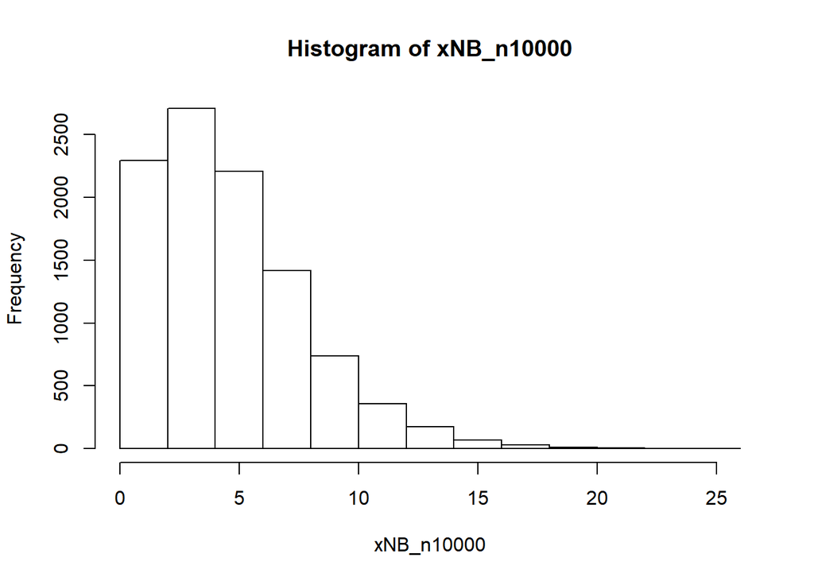

```r
hist(xNB_n10000)
```

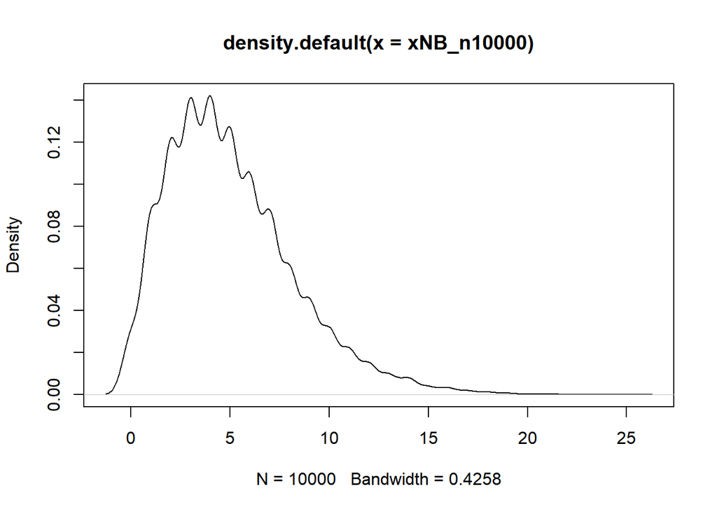

```r
plot(density(xNB_n10000))
```

Poisson - discrete

```r
summary(xP_n10000)
```

```
##    Min. 1st Qu.  Median    Mean 3rd Qu.    Max.
##   0.000   2.000   3.000   3.008   4.000  12.000
```

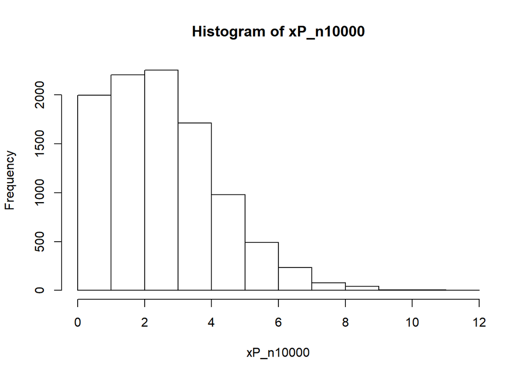

```r
hist(xP_n10000)
```

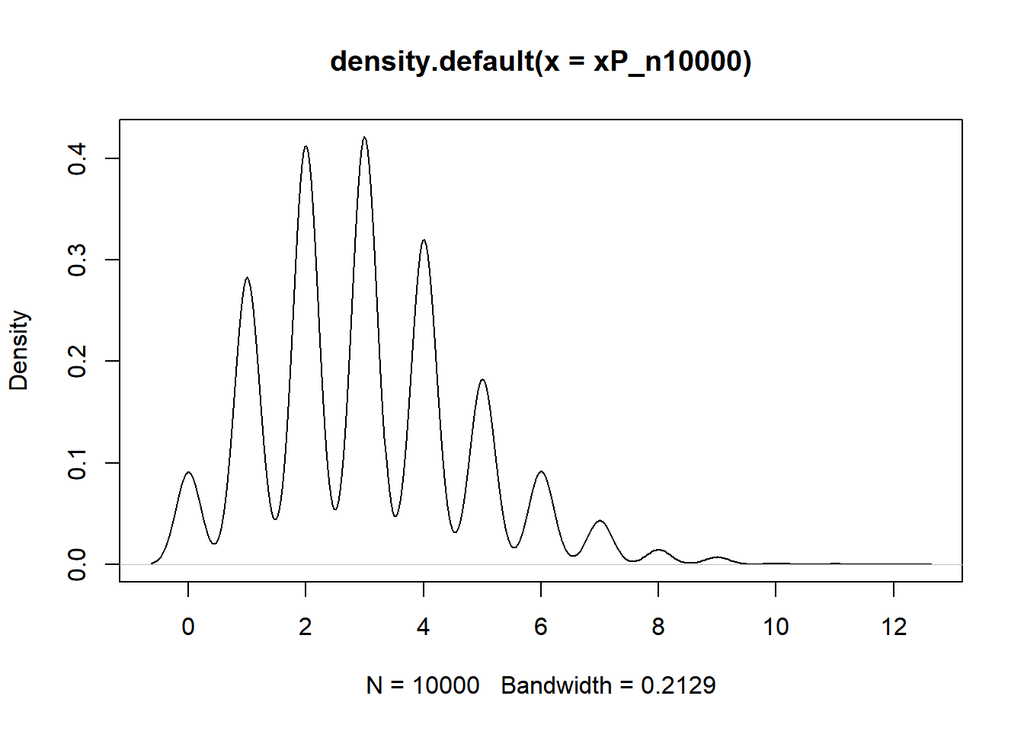

```r
plot(density(xP_n10000))
```

### 5. Contrast the 5-Number Summaries at each of the sample sizes (6, 10, 20, 30, 50, and 10000) for the skewed distributions (Negative binomial, $Chi^2$, $F$, Poisson) vs. the symmetric distributions (Binomial, $t$, Normal).

The summaries for Symmetric distributions explaine the distributions more accurately as sample size increases. The summaries of the Skewed distributions vary without a certain pattern when sample size increases.

Normal - symmetric

```r
summary(NormSubs6)
```

```
##    Min. 1st Qu.  Median    Mean 3rd Qu.    Max.
##  0.1315  0.2738  1.5049  1.9351  2.6553  5.5672
```

```r
summary(NormSubs10)
```

```
##    Min. 1st Qu.  Median    Mean 3rd Qu.    Max.
##  0.1315  0.7787  2.5737  2.2956  3.2381  5.5672
```

```r
summary(NormSubs20)
```

```
##    Min. 1st Qu.  Median    Mean 3rd Qu.    Max.
##  -2.952   1.141   2.804   2.426   3.697   5.567
```

```r
summary(NormSubs30)
```

```
##    Min. 1st Qu.  Median    Mean 3rd Qu.    Max.
##  -2.952   1.027   2.574   2.184   3.585   5.567
```

```r
summary(NormSubs50)
```

```
##    Min. 1st Qu.  Median    Mean 3rd Qu.    Max.
##  -2.952   1.168   2.289   2.225   3.628   5.567
```

```r
summary(xNorm_n10000)
```

```
##    Min. 1st Qu.  Median    Mean 3rd Qu.    Max.
## -6.2093  0.4942  1.9644  1.9854  3.5153 10.5200
```

```r
var(NormSubs6)
```

```
## [1] 4.446056
```

```r
var(NormSubs10)
```

```
## [1] 3.046572
```

```r
var(NormSubs30)
```

```
## [1] 4.269997
```

```r
var(NormSubs50)
```

```
## [1] 3.456079
```

```r
var(xNorm_n10000)
```

```
## [1] 5.124328
```

Student’s $t$ - symmetric

```r
summary(TSubs6)
```

```
##     Min.  1st Qu.   Median     Mean  3rd Qu.     Max.
## -0.96300 -0.14891  0.03367  0.61769  1.06361  3.40464
```

```r
summary(TSubs10)
```

```
##    Min. 1st Qu.  Median    Mean 3rd Qu.    Max.
## -0.9630 -0.1489  0.5992  0.9656  1.2625  4.7326
```

```r
summary(TSubs20)
```

```
##    Min. 1st Qu.  Median    Mean 3rd Qu.    Max.
## -2.3694 -0.5698  0.2301  0.4317  1.0323  4.7326
```

```r
summary(TSubs30)
```

```
##     Min.  1st Qu.   Median     Mean  3rd Qu.     Max.
## -2.36936 -0.66960  0.03367  0.29728  1.09720  4.73264
```

```r
summary(TSubs50)
```

```
##    Min. 1st Qu.  Median    Mean 3rd Qu.    Max.
## -2.3694 -0.5108  0.2383  0.4470  1.3048  4.7326
```

```r
summary(xrt_n10000)
```

```
##       Min.    1st Qu.     Median       Mean    3rd Qu.       Max.
## -16.581973  -0.744999  -0.004989  -0.014118   0.742671  13.393131
```

```r
var(TSubs6)
```

```
## [1] 2.42724
```

```r
var(TSubs10)
```

```
## [1] 3.343344
```

```r
var(TSubs20)
```

```
## [1] 2.523075
```

```r
var(TSubs30)
```

```
## [1] 2.245901
```

```r
var(TSubs50)
```

```
## [1] 1.95557
```

```r
var(xrt_n10000)
```

```
## [1] 2.018343
```

Binomial-symmetric

```r
summary(BDSubs6)
```

```
##    Min. 1st Qu.  Median    Mean 3rd Qu.    Max.
##       4       5       6       6       7       8
```

```r
summary(BDSubs10)
```

```
##    Min. 1st Qu.  Median    Mean 3rd Qu.    Max.
##     4.0     5.0     5.5     5.9     7.0     8.0
```

```r
summary(BDSubs20)
```

```
##    Min. 1st Qu.  Median    Mean 3rd Qu.    Max.
##       4       5       6       6       7       8
```

```r
summary(BDSubs30)
```

```
##    Min. 1st Qu.  Median    Mean 3rd Qu.    Max.
##   3.000   5.000   6.000   5.933   7.000   8.000
```

```r
summary(BDSubs50)
```

```
##    Min. 1st Qu.  Median    Mean 3rd Qu.    Max.
##    3.00    5.00    6.00    6.06    7.00    9.00
```

```r
summary(xBD_n10000)
```

```
##    Min. 1st Qu.  Median    Mean 3rd Qu.    Max.
##   1.000   5.000   6.000   5.992   7.000   9.000
```

```r
var(BDSubs6)
```

```
## [1] 2.4
```

```r
var(BDSubs10)
```

```
## [1] 2.322222
```

```r
var(BDSubs20)
```

```
## [1] 1.578947
```

```r
var(BDSubs30)
```

```
## [1] 1.995402
```

```r
var(BDSubs50)
```

```
## [1] 1.812653
```

```r
var(BDSubs6)
```

```
## [1] 2.4
```

```r
var(xBD_n10000)
```

```
## [1] 2.016938
```

$F$-Distribution - skewed

```r
summary(FSubs6)
```

```
##    Min. 1st Qu.  Median    Mean 3rd Qu.    Max.
##  0.5374  0.7094  1.1642  1.1845  1.3596  2.2585
```

```r
summary(FSubs10)
```

```
##    Min. 1st Qu.  Median    Mean 3rd Qu.    Max.
##  0.5374  0.7006  1.0532  1.1032  1.3596  2.2585
```

```r
summary(FSubs20)
```

```
##    Min. 1st Qu.  Median    Mean 3rd Qu.    Max.
##  0.4773  0.6777  1.1642  1.1271  1.3709  2.2585
```

```r
summary(FSubs30)
```

```
##    Min. 1st Qu.  Median    Mean 3rd Qu.    Max.
##  0.4773  0.7089  1.1642  1.1179  1.3487  2.2585
```

```r
summary(FSubs50)
```

```
##    Min. 1st Qu.  Median    Mean 3rd Qu.    Max.
##  0.4562  0.6985  1.1751  1.1669  1.4245  2.9828
```

```r
summary(xFd_n10000)
```

```
##    Min. 1st Qu.  Median    Mean 3rd Qu.    Max.
##  0.2492  0.7955  1.0512  1.1985  1.4383  7.3203
```

```r
var(FSubs6)
```

```
## [1] 0.4046693
```

```r
var(FSubs10)
```

```
## [1] 0.2821754
```

```r
var(FSubs20)
```

```
## [1] 0.2335248
```

```r
var(FSubs30)
```

```
## [1] 0.189363
```

```r
var(FSubs50)
```

```
## [1] 0.2654681
```

```r
var(xFd_n10000)
```

```
## [1] 0.3668258
```

Negative binomial - skewed

```r
summary(NegSubs6)
```

```
##    Min. 1st Qu.  Median    Mean 3rd Qu.    Max.
##    2.00    3.00    3.50    4.50    6.25    8.00
```

```r
summary(NegSubs10)
```

```
##    Min. 1st Qu.  Median    Mean 3rd Qu.    Max.
##     2.0     3.0     4.5     5.0     7.0     9.0
```

```r
summary(NegSubs20)
```

```
##    Min. 1st Qu.  Median    Mean 3rd Qu.    Max.
##    2.00    3.00    5.50    6.20    8.25   15.00
```

```r
summary(NegSubs30)
```

```
##    Min. 1st Qu.  Median    Mean 3rd Qu.    Max.
##   2.000   3.250   5.000   5.767   7.000  15.000
```

```r
summary(NegSubs50)
```

```
##    Min. 1st Qu.  Median    Mean 3rd Qu.    Max.
##    0.00    3.00    5.00    5.38    7.00   15.00
```

```r
summary(xNB_n10000)
```

```
##    Min. 1st Qu.  Median    Mean 3rd Qu.    Max.
##   0.000   3.000   5.000   5.036   7.000  25.000
```

```r
var(NegSubs6)
```

```
## [1] 5.9
```

```r
var(NegSubs10)
```

```
## [1] 6.666667
```

```r
var(NegSubs20)
```

```
## [1] 12.58947
```

```r
var(NegSubs30)
```

```
## [1] 9.633333
```

```r
var(NegSubs50)
```

```
## [1] 9.260816
```

```r
var(xNB_n10000)
```

```
## [1] 10.47404
```

Poisson - skewed

```r
summary(PoisSubs6)
```

```
##    Min. 1st Qu.  Median    Mean 3rd Qu.    Max.
##    1.00    1.25    2.00    3.00    3.50    8.00
```

```r
summary(PoisSubs10)
```

```
##    Min. 1st Qu.  Median    Mean 3rd Qu.    Max.
##    1.00    1.25    2.00    3.10    3.75    8.00
```

```r
summary(PoisSubs20)
```

```
##    Min. 1st Qu.  Median    Mean 3rd Qu.    Max.
##    0.00    1.00    2.00    2.75    3.25    8.00
```

```r
summary(PoisSubs30)
```

```
##    Min. 1st Qu.  Median    Mean 3rd Qu.    Max.
##   0.000   1.250   2.500   3.267   4.000   9.000
```

```r
summary(PoisSubs50)
```

```
##    Min. 1st Qu.  Median    Mean 3rd Qu.    Max.
##    0.00    2.00    3.00    3.32    4.75    9.00
```

```r
summary(xP_n10000)
```

```
##    Min. 1st Qu.  Median    Mean 3rd Qu.    Max.
##   0.000   2.000   3.000   3.008   4.000  12.000
```

```r
var(PoisSubs6)
```

```
## [1] 7.2
```

```r
var(PoisSubs10)
```

```
## [1] 6.322222
```

```r
var(PoisSubs20)
```

```
## [1] 5.039474
```

```r
var(PoisSubs30)
```

```
## [1] 6.271264
```

```r
var(PoisSubs50)
```

```
## [1] 4.793469
```

```r
var(xP_n10000)
```

```
## [1] 3.026635
```